# bcRep: Advanced Analysis of B Cell Receptor Repertoire Data

## Amino acid distribution

Amino acid distribution can be analyzed using `aaDistribution()` and visualized with `plotAADistribution()`.

This function returns a list containing proportions of all amino acids (including stop codons “*“) for each analyzed sequence length. Optionally, also the number used for analysis can be given.

Figures can be saved as PDF in the working directory.

```r
# Example:
data(aaseqtab)
aadistr<-aaDistribution(sequences = aaseqtab$CDR3_IMGT, numberSeq = TRUE)

# First 4 columns of Amino acid distribution table:
        # for a sequence length of 13 AA (* = stop codon)
        # (aadistr$Amino_acid_distribution$`sequence length = 13`)
```

|  | Position1 | Position2 | Position3 | Position4 |
| --- | --- | --- | --- | --- |
| **F** | 0 | 0 | 0.007018 | 0.01053 |
| **L** | 0 | 0.003509 | 0.04561 | 0.08772 |
| **I** | 0 | 0.02105 | 0.02456 | 0.03158 |
| **M** | 0 | 0 | 0.01404 | 0.01754 |
| **V** | 0.003509 | 0.007018 | 0.09123 | 0.04561 |
| **S** | 0 | 0.07719 | 0.08421 | 0.07368 |
| **P** | 0.003509 | 0 | 0.02105 | 0.07018 |
| **T** | 0.02105 | 0.05614 | 0 | 0.03158 |
| **A** | 0.9614 | 0.003509 | 0.05965 | 0.05614 |
| **Y** | 0 | 0 | 0.01754 | 0.05263 |
| **H** | 0 | 0.01404 | 0.01053 | 0.007018 |
| **C** | 0 | 0 | 0.02105 | 0.007018 |
| **W** | 0 | 0 | 0.007018 | 0.02807 |
| **N** | 0 | 0.01404 | 0.007018 | 0.04211 |
| **D** | 0 | 0 | 0.2281 | 0.06316 |
| **G** | 0.003509 | 0.01053 | 0.1825 | 0.207 |
| **Q** | 0 | 0 | 0.01053 | 0.01404 |
| **R** | 0.007018 | 0.607 | 0.06316 | 0.0807 |
| **K** | 0 | 0.186 | 0.007018 | 0.03509 |
| **E** | 0 | 0 | 0.09825 | 0.0386 |
| ***** | 0 | 0 | 0 | 0 |

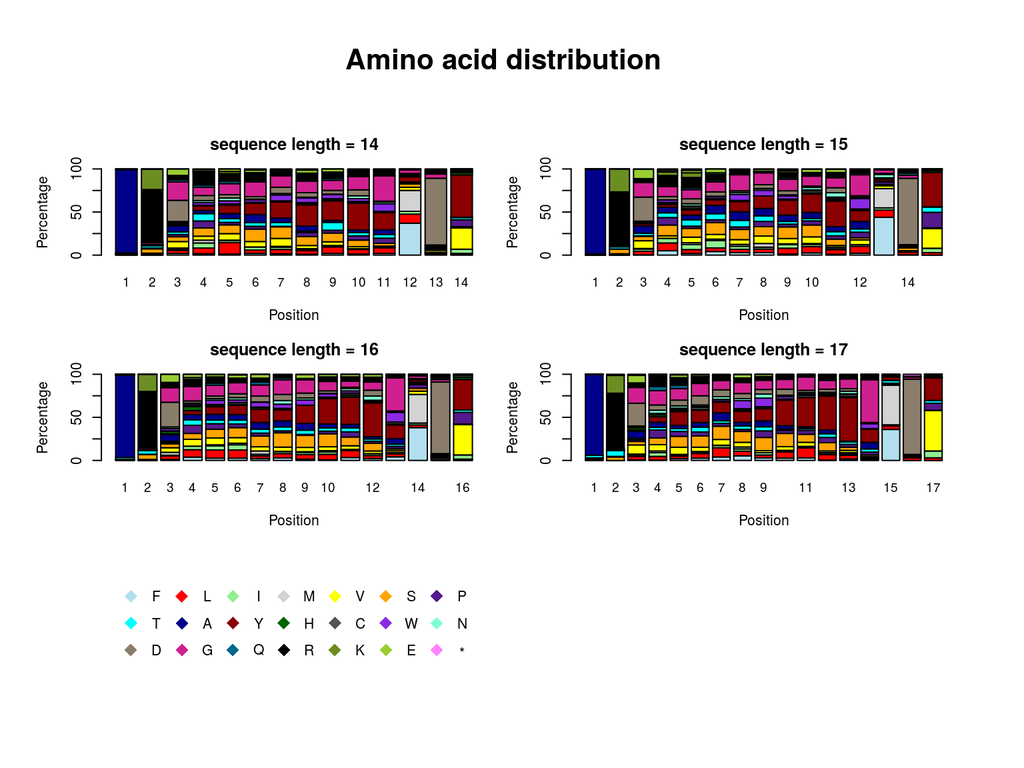

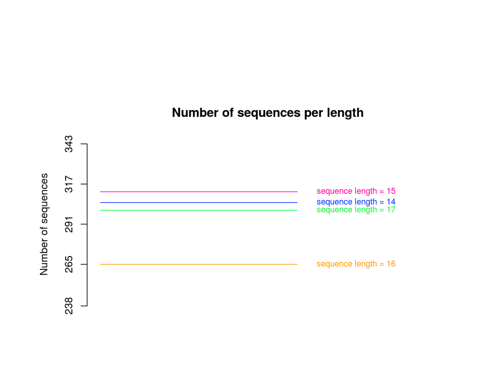

```r
# Plot example for sequence lengths of 14-17 amino acids:
aadistr.part<-list(aadistr$Amino_acid_distribution[13:16],
                   data.frame(aadistr$Number_of_sequences_per_length[13:16,]))
names(aadistr.part)<-names(aadistr)
plotAADistribution(aaDistribution.tab=aadistr.part, plotAADistr=TRUE,
                   plotSeqN=TRUE, PDF=NULL)
```

## Diversity

Diversity of sequences and clones can be analyzed using `trueDiversity()` or `clones.giniIndex()`.

### True diversity

Using `trueDiversity()` richness or diversity of sequences with the same length can be analyzed. Basically diversity of amino acids at each position is calculated. True diversity can be measured for orders q = 0, 1 or 2. `plotTrueDiversity()` can be used for visualization. If `mean.plot = F`, a figure for each sequence length including diversity per position will be returned. If `mean.plot = T` only one figure with mean diversity values for all sequences with the same length will be returned.

Order 0: Richness (in this case it represents number of different amino acids per position).

Order 1: Exponential function of Shannon entropy using the natural logarithm (weights all amino acids by their frequency).

Order 2: Inverse Simpson entropy (weights all amino acids by their frequency, but weights are given more to abundant amino acids).

These indices are very similar (Hill, 1973). For example the exponential function of Shannon index is linearly related to inverse Simpson.

Amino acid sequences can be found in IMGT output table `5_AA-sequences(...).txt`.

```r
# Example:
data(aaseqtab)
trueDiv<-trueDiversity(sequences = aaseqtab$CDR3_IMGT, order = 1)
        # using exponent of Shannon entropy

# True diversity of order 1 for amino acid length of 5 AA
        # (trueDiv$True_diversity$'sequence length = 5')
```

| Position1 | Position2 | Position3 | Position4 | Position5 |
| --- | --- | --- | --- | --- |
| 1 | 3 | 3 | 1.89 | 3 |

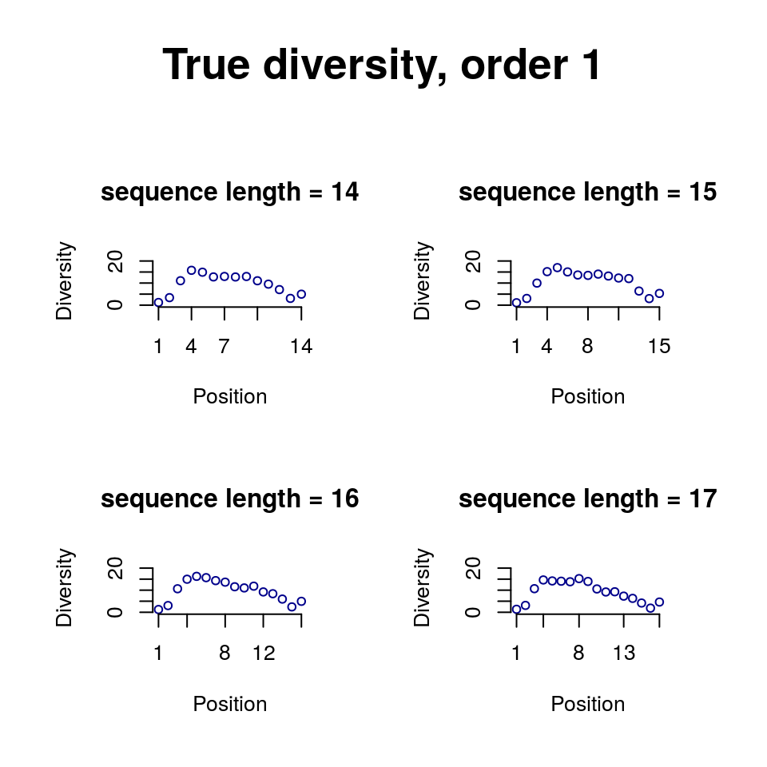

```r
# True diversity for sequences of amino acid length 14-17:
trueDiv.part<-list(trueDiv$True_diversity_order, trueDiv$True_diversity[13:16])
names(trueDiv.part)<-names(trueDiv)
plotTrueDiversity(trueDiversity.tab=trueDiv.part, mean.plot = F,color="darkblue", PDF=NULL)
```

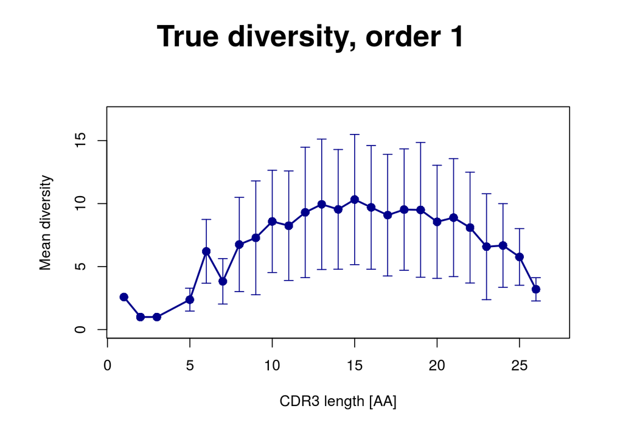

```r
plotTrueDiversity(trueDiversity.tab=trueDiv, mean.plot = T,color="darkblue", PDF=NULL)
```

### Gini index

‘clones.giniIndex()’ calculates the Gini index of clones. Input is a vector containing clone sizes (copy number). The Gini index measures the inequality of clone size distribution. It ranges between 0 and 1. An index of 0 represents a polyclonal distribution, where all clones have same size. An index of 1 represents a perfect monoclonal distribution.

If a PDF project name is given, the Lorenz curve will be returned, as well. Lorenz curve can be interpreted as p*100 percent have L(p)*100 percent of clone size.

```r
# Example:
data(clones.ind)
clones.giniIndex(clone.size=clones.ind$total_number_of_sequences, PDF = NULL)
# [1] 0.7473557
```

## Gene usage

Gene usage can be analyzed using functions `geneUsage()` and `sequences.geneComb()`.

It can be differentiated between subgroup (e.g. IGHV1), gene (e.g. IGHV1-1) or allele (e.g. IGHV1-1*2), as well as between relative or absolute values.

When using function `geneUsage()`, functionality and junction frame usage, dependent on gene usage can be studied. Please note, that input vectors have to have the same order. Single genes per line, as well as several genes per line, can be processed. IMGT nomenclature has to be used (e.g. “Homsap IGHV4-34*01“)!

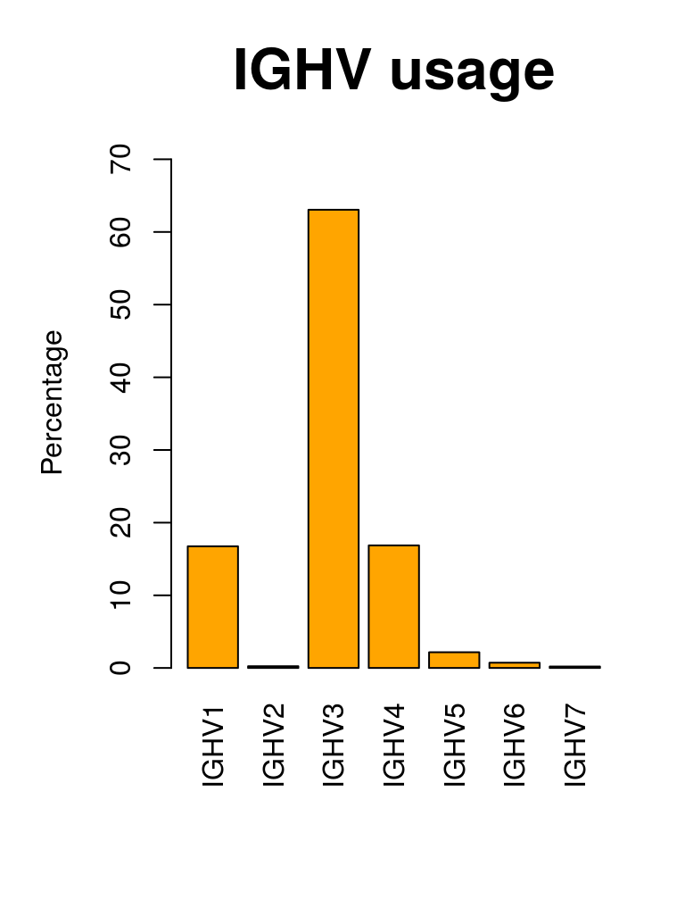

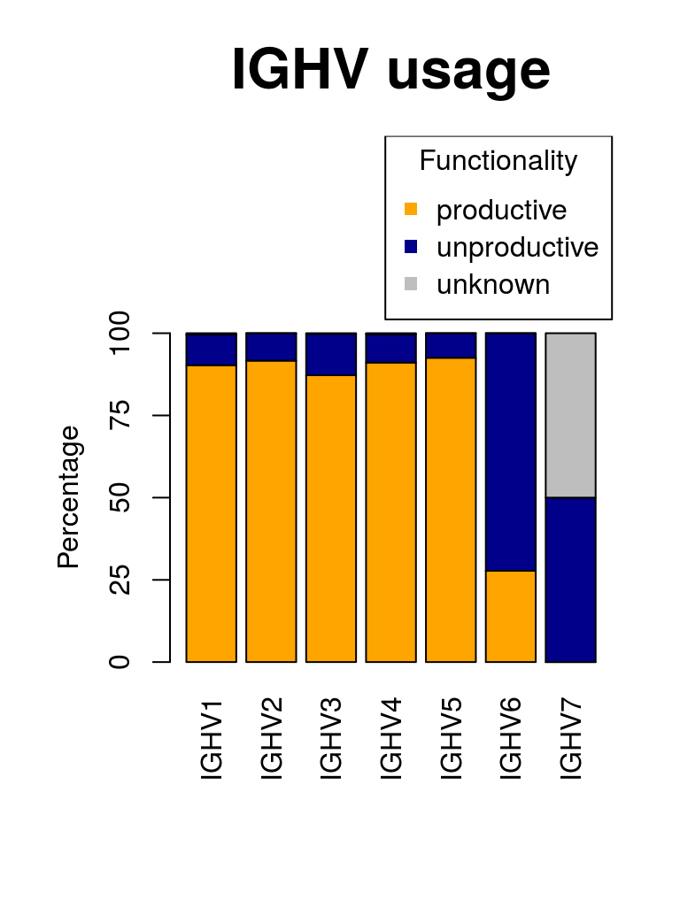

```r
# Example:
data(summarytab)
Vgu<-geneUsage(genes = summarytab$V_GENE_and_allele, level = "subgroup",
                functionality = summarytab$Functionality)
plotGeneUsage(geneUsage.tab = Vgu, plotFunctionality = TRUE, PDF = NULL,
              title = "IGHV usage")
```

Using function `sequences.geneComb()`, gene/gene ratios of two gene families will be analyzed. IMGT nomenclature has to be used (e.g. “Homsap IGHV4-34*01“). Results can be plotted with and without gene/gene combinations, where one or both genes are unknown.

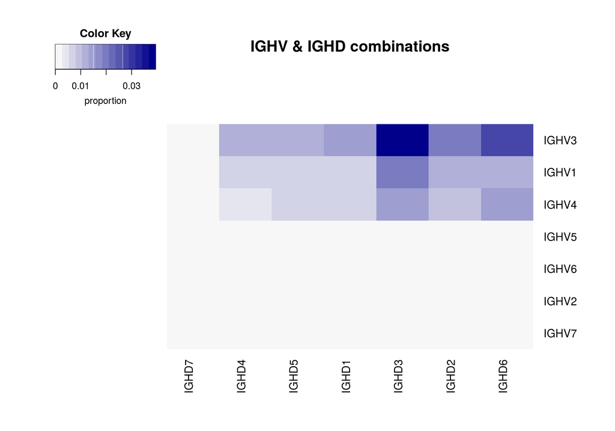

```r
# Example:
data(summarytab)
VDcomb.tab<-sequences.geneComb(family1 = summarytab$V_GENE_and_allele,
                family2 = summarytab$D_GENE_and_allele,
                level = "subgroup", abundance = "relative")
plotGeneComb(geneComb.tab = VDcomb.tab, withNA = FALSE, PDF = NULL)
```

## Functions for a set of sequences

Function to filter and to summarize IMGT/HighV-QUEST are provided:

### Filter sequences

Sequence files can be filtered for functionality or junction frame usage:

- sequences.getProductives(): filters for productive sequences
- sequences.getUnproductives(): filters for unproductive sequences
- sequences.getAnyFunctionality(): excludes sequences without any functionality information
- sequences.getInFrames(): filters for in-frame sequences
- sequences.getOutOfFrames(): filters for out-of-frame sequences
- sequences.getAnyJunctionFrame(): excludes sequences without any junction frame information

The function looks for a column containing functionality or junction frame information and filters the whole table. Columns will remain, rows will be filtered. Junction frame information is only available in the IMGT summary table (`1_Summary(...).txt`). Functionality information is available in every table.

```r
# Example: filter for productive sequences
data(summarytab)
ProductiveSequences<-sequences.getProductives(summarytab)
# dimension of the summary table [rows, columns]:
dim(summarytab)
## [1] 3000   29
# dimension of the summary table, filtered for productive sequences [rows, columns]:
dim(ProductiveSequences)
## [1] 2645   29
```

### Functionality and junction frames

Some basic statistics about functionality and junction frames can be given by `sequences.functionality()` and `sequences.junctionFrame()`. Both functions return absolute or relative values for each kind of sequences.

```r
# Example:
data(summarytab)
sequences.functionality(data = summarytab$Functionality, relativeValues=TRUE)

# Proportion of productive and unproductive sequences:
```

| productive | unproductive | unknown |
| --- | --- | --- |
| 0.8817 | 0.1127 | 0.005667 |

### Mutations

Some basic mutation analysis can be done with `sequences.mutation()`. Input is the IMGT output table `7_V-REGION-mutation-and-AA-change-table(...).txt` and optionally `1_Summary(...).txt`. Mutation analysis can be done for V-region, FR1-3 and CDR1-2 sequences. Functionality, as well as junction frame analysis can be included. Further the R/S ratio (ratio of replacement and silent mutations) can be returned.

```r
data(mutationtab)
V.mutation<-sequences.mutation(mutationtab = mutationtab, sequence = "V",
                               junctionFr = TRUE, rsRatio=TRUE)

# V.mutation$Number_of_mutations, first 6 lines:
```

|  | number_mutations | number_replacement | number_silent | RS_ratio |
| --- | --- | --- | --- | --- |
| **Sequence1** | 1 | 1 | 0 | 0 |
| **Sequence2** | 0 | 0 | 0 | 0 |
| **Sequence3** | 1 | 0 | 1 | 0 |
| **Sequence4** | 7 | 4 | 3 | 1.333 |
| **Sequence5** | 29 | 21 | 8 | 2.625 |
| **Sequence6** | 3 | 1 | 2 | 0.5 |

```r
# V.mutation$Junction frame:
```

|  | proportion |
| --- | --- |
| **mutation_in_in-frame_sequences** | 0 |
| **mutations_in_out-of-frame_sequences** | 0 |
| **mutations_in_sequences_with_unknown_junction_frame** | 0.7387 |
| **no_mutation_in_in-frame_sequences** | 0 |
| **no_mutations_in_out-of-frame_sequences** | 0 |
| **no_mutations_in_sequences_with_unknown_junction_frame** | 0.2613 |

#### Proportions of nucleotides at and nearby mutation sites

Proportions of nucleotide distributions at and nearby mutation sites can be calculated using `sequences.mutation.base()`. This function calculates the porportion of a, c, g or t at the mutated positions and/or next to mutations from position -3 to +3. Parallel processing can be used for large datasets.

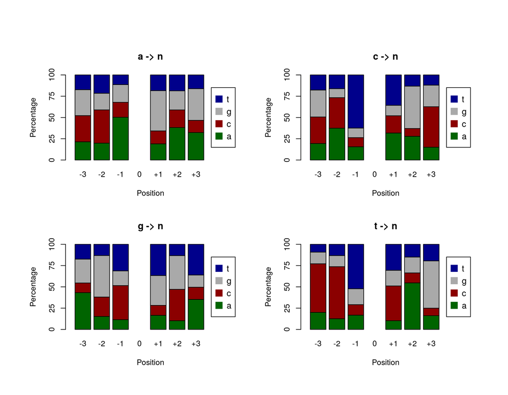

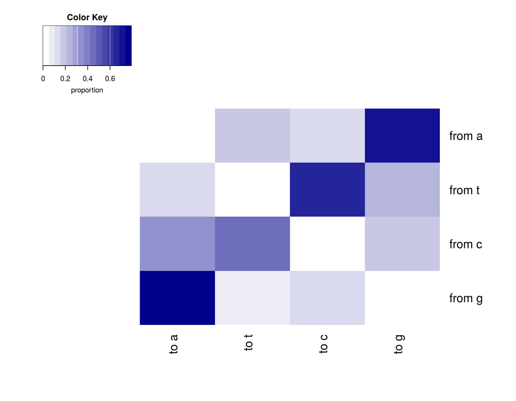

```r
# Example:

data(mutationtab)
data(summarytab)
V.BaseMut<-sequences.mutation.base(mutationtab = mutationtab, summarytab = summarytab,
                                   analyseEnvironment = TRUE, analyseMutation = TRUE,
                                   sequence = "V", nrCores=1)
plotSequencesMutationBase(mutationBaseTab = V.BaseMut, plotEnvironment = TRUE,
     plotMutation = TRUE, colHeatmap = c("white","darkblue"))
```

#### Proportions of amino acid changes

Proportions of amino acid changes can be calculated using `sequences.mutation.AA()`. This function calculates the porportion of mutations from amino acid x to amino acid y. The original amino acids are in rows, the mutated one in columns.

`plotSequencesMutationAA()` visualizes the 20 x 20 data frame in some kind of heatmap, showing groups of proportions. Furthermore changes of amino acid characteristics, like hydropathy, volume or chemical can be shown (orange dots). Figures can be saved as PDF.

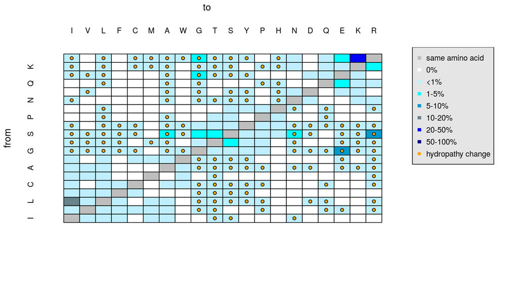

```r
# Example:

data(mutationtab)
V.AAmut<-sequences.mutation.AA(mutationtab = mutationtab, sequence = "V")
plotSequencesMutationAA(mutationAAtab = V.AAmut, showChange = "hydropathy")
```

## Functions for a set of clones

bcRep provides some functions to study clone features. Some columns of the clonotype file can simply be plotted using `boxplot()` or `barplot()`.

### Defining clones and shared clones

Clones can be defined from a set of sequences, using `clones()`. Criteria for sequences, belonging to the same clones are:

- same CDR3 (amino acid) length and a identity of a given treshold (it’s possible, to look for same CDR3 sequences or for a CDR3 identity of e.g. 85%)
- same V gene
- same J gene (optional)

Output of the clone table can be individually specified (see help), but following columns are mandatory:

- Shared CDR3 amino acid sequence(s)
- CDR3 amino acid sequence length
- Number of unique CDR3 sequences (each CDR3 sequence is mentioned once)
- Number of all CDR3 sequences (CDR3 sequences are listed with duplicates)
- Sequence count per CDR3
- V gene (as used for analysis)
- V gene and allele (IMGT nomenclature)
- J gene (as used for analysis)
- J gene and allele (IMGT nomenclature)

Optionally columns like D gene, CDR3 amino acid sequences, CDR3 nucleotide sequences, functionality, junction frames and so on, can be specified.

Further the function `clones.IDlist()` returns a table containing all sequence ID’s provided in the IMGT tables and correpsonding clone ID’s. This function only works, if sequence ID’s were returned in clone table [`clones(..., dispSeqID = TRUE)`]. So you can get information about which sequence belongs to which clone or even which sequences were not matched to any of those clones.

```r
# Example:
data(aaseqtab)
data(summarytab)
clones.tab<-clones(aaseqtab = aaseqtab, summarytab = summarytab, ntseqtab = NULL,
                   identity = 0.85, useJ = TRUE, dispD = FALSE, dispSeqID = FALSE,
                   dispCDR3aa = FALSE, dispCDR3nt = FALSE,
                   dispJunctionFr.ratio = FALSE, dispJunctionFr.list = FALSE,
                   dispFunctionality.ratio = FALSE, dispFunctionality.list = FALSE,
                   dispTotalSeq = FALSE, nrCores=1)
```

```r
# Example of a clonotype file (not from the command above)
data(clones.ind)
str(clones.ind, strict.width="cut", width=85)
```

```
## 'data.frame':    1000 obs. of  14 variables:
##  $ unique_CDR3_sequences_AA    : chr  "ARERADY, AKERADY, AGERADY" "AKDSDPTV, AKDSD"..
##  $ CDR3_length_AA              : num  7 8 8 8 8 8 8 9 10 10 ...
##  $ number_of_unique_sequences  : num  3 2 2 2 2 3 2 2 2 2 ...
##  $ total_number_of_sequences   : num  45 12 243 130 14 244 59 68 44 296 ...
##  $ sequence_count_per_CDR3     : chr  "42, 2, 1" "11, 1" "242, 1" "129, 1" ...
##  $ V_gene                      : chr  "IGHV3-30-3" "IGHV3-30-3" "IGHV3-30-3" "IGHV"..
##  $ V_gene_and_allele           : chr  "Homsap IGHV3-30-3*01 F, Homsap IGHV3-30*04 "..
##  $ J_gene                      : chr  "IGHJ4" "IGHJ4" "IGHJ4" "IGHJ4" ...
##  $ J_gene_and_allele           : chr  "Homsap IGHJ4*02 F" "Homsap IGHJ4*02 F" "Hom"..
##  $ D_gene                      : chr  "Homsap IGHD1-1*01 F, Homsap IGHD4-17*01 F, "..
##  $ all_CDR3_sequences_AA       : chr  "ARERADY, ARERADY, ARERADY, ARERADY, ARERADY"..
##  $ all_CDR3_sequences_nt       : chr  "gcgagagaacgggctgactac, gcgagagaacgggctgacta"..
##  $ Functionality_all_sequences : chr  "productive, productive, unproductive, produ"..
##  $ Junction_frame_all_sequences: chr  "in-frame, in-frame, in-frame, in-frame, in-"..
```

```r
data(aaseqtab)
data(summarytab)
clones.tab<-clones(aaseqtab = aaseqtab, summarytab = summarytab, dispSeqID = T)
clones.ID<-clones.IDlist(clones.seqID = clones.tab$Sequence_IDs, summarytab.seqID = summarytab$Sequence_ID)
clones.ID[1:5,] # Example of output of clones.IDlist()
```

```
##   Sequence_ID  Clone_ID
## 1   Sequence1  no_clone
## 2   Sequence2  clone_42
## 3   Sequence3  no_clone
## 4   Sequence4 clone_141
## 5   Sequence5  clone_95
```